# Climate-Project 3 (1) (1)

```python
import datetime
import numpy as np
import pandas as pd
from sklearn.metrics import mean_squared_error
import matplotlib.pyplot as plt
import seaborn as sns
from statsmodels.tsa.statespace.sarimax import SARIMAX
from statsmodels.tsa.arima.model import ARIMA
from statsmodels.tsa.seasonal import seasonal_decompose
```

```python
climate=pd.read_csv("C:\\Users\\Jordy\\Desktop\\DailyDelhiClimateTrain.csv")
```

```python
climate.head()
```

|  | date | meantemp | humidity | wind_speed | meanpressure |
| --- | --- | --- | --- | --- | --- |
| 0 | 2013-01-01 | 10.000000 | 84.500000 | 0.000000 | 1015.666667 |
| 1 | 2013-01-02 | 7.400000 | 92.000000 | 2.980000 | 1017.800000 |
| 2 | 2013-01-03 | 7.166667 | 87.000000 | 4.633333 | 1018.666667 |
| 3 | 2013-01-04 | 8.666667 | 71.333333 | 1.233333 | 1017.166667 |
| 4 | 2013-01-05 | 6.000000 | 86.833333 | 3.700000 | 1016.500000 |

# Understanding our data/checking for null values

```python
climate.info()
```

```
<class 'pandas.core.frame.DataFrame'>
RangeIndex: 1462 entries, 0 to 1461
Data columns (total 5 columns):
 #   Column        Non-Null Count  Dtype
---  ------        --------------  -----
 0   date          1462 non-null   object
 1   meantemp      1462 non-null   float64
 2   humidity      1462 non-null   float64
 3   wind_speed    1462 non-null   float64
 4   meanpressure  1462 non-null   float64
dtypes: float64(4), object(1)
memory usage: 57.2+ KB
```

```python
climate.isnull().sum()
```

```
date            0
meantemp        0
humidity        0
wind_speed      0
meanpressure    0
dtype: int64
```

##### We have 5 different columns in our data. Date is for the date we are observing. Meantemp is the mean temperature on a given day. Humidity is for the observed humidy on a given day. Wind speed measures the wind speed on given day. Meanpressure is the mean of the air pressure observed on that given day. we will monitor all these features to see how they interact with each other and develop a model to be able to predict the temperature on "x" days after the last day observed.

# Formatting our date

```python
#Changing the data type for date
climate['date'] = pd.to_datetime(climate['date'])
climate.info()
```

```
<class 'pandas.core.frame.DataFrame'>
RangeIndex: 1462 entries, 0 to 1461
Data columns (total 5 columns):
 #   Column        Non-Null Count  Dtype
---  ------        --------------  -----
 0   date          1462 non-null   datetime64[ns]
 1   meantemp      1462 non-null   float64
 2   humidity      1462 non-null   float64
 3   wind_speed    1462 non-null   float64
 4   meanpressure  1462 non-null   float64
dtypes: datetime64[ns](1), float64(4)
memory usage: 57.2 KB
```

```python
#Indexing date
climate.set_index('date', inplace=True)
climate.info()
```

```
<class 'pandas.core.frame.DataFrame'>
DatetimeIndex: 1462 entries, 2013-01-01 to 2017-01-01
Data columns (total 4 columns):
 #   Column        Non-Null Count  Dtype
---  ------        --------------  -----
 0   meantemp      1462 non-null   float64
 1   humidity      1462 non-null   float64
 2   wind_speed    1462 non-null   float64
 3   meanpressure  1462 non-null   float64
dtypes: float64(4)
memory usage: 57.1 KB
```

# EDA of our features

```
*c* argument looks like a single numeric RGB or RGBA sequence, which should be avoided as value-mapping will have precedence in case its length matches with *x* & *y*.  Please use the *color* keyword-argument or provide a 2D array with a single row if you intend to specify the same RGB or RGBA value…
```

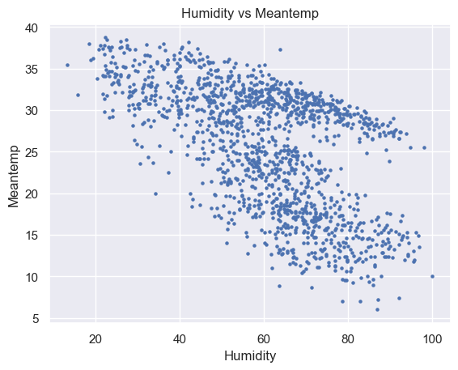

```python
climate.plot.scatter(x='humidity',y='meantemp',s=5)
plt.title('Humidity vs Meantemp')
plt.xlabel('Humidity')
plt.ylabel('Meantemp')
```

##### Seems to be a relatively strong negative correlation between humidity and temperature. It looks like the higher the temperature the lower the humidity is.

```
*c* argument looks like a single numeric RGB or RGBA sequence, which should be avoided as value-mapping will have precedence in case its length matches with *x* & *y*.  Please use the *color* keyword-argument or provide a 2D array with a single row if you intend to specify the same RGB or RGBA value…
```

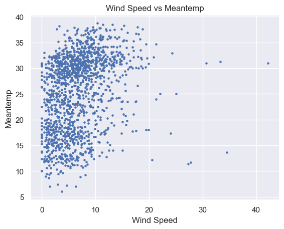

```python
climate.plot.scatter(x='wind_speed',y='meantemp',s=5)
plt.title('Wind Speed vs Meantemp')
plt.xlabel('Wind Speed')
plt.ylabel('Meantemp')
```

##### There doesn't seem to be much of a correlation here. Nothing to necessarily note.

```
*c* argument looks like a single numeric RGB or RGBA sequence, which should be avoided as value-mapping will have precedence in case its length matches with *x* & *y*.  Please use the *color* keyword-argument or provide a 2D array with a single row if you intend to specify the same RGB or RGBA value…
```

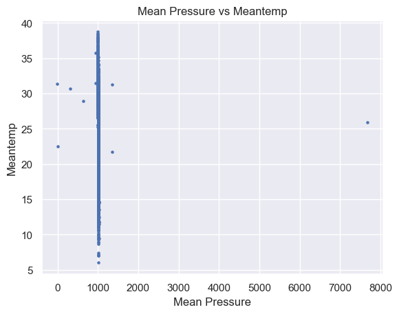

```python
climate.plot.scatter(x='meanpressure',y='meantemp',s=5)
plt.title('Mean Pressure vs Meantemp')
plt.xlabel('Mean Pressure')
plt.ylabel('Meantemp')
```

##### Again I don't see any glaring correlation to write about. Seems to be that the mean air pressure stays around 1000.

```python
corr=climate.corr()
corr.style.background_gradient(cmap='coolwarm')
```

|  | meantemp | humidity | wind_speed | meanpressure |
| --- | --- | --- | --- | --- |
| meantemp | 1.000000 | -0.571951 | 0.306468 | -0.038818 |
| humidity | -0.571951 | 1.000000 | -0.373972 | 0.001734 |
| wind_speed | 0.306468 | -0.373972 | 1.000000 | -0.020670 |
| meanpressure | -0.038818 | 0.001734 | -0.020670 | 1.000000 |

##### Here we can see what we have already observed in that humidy has a decently strong negative correlation with meantemp. It is also important to note the correlation that wind speed has with mean temp. It is a slightly positive correlation. Although it isn't ver strong, it is important to note.

# Plotting our data for visualization

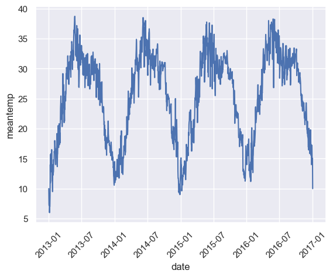

```python
sns.set()
plt.ylabel('meantemp')
plt.xlabel('date')
plt.xticks(rotation=45)
plt.plot(climate.index, climate['meantemp'], )
```

###### Here, it is evident that we have some sort of seasonality, we can see that by the regular and almost predictable lows and highs when we visualized our data. In terms of a trend, I don't necessarily see any, or a strong sign of one but we will further explore this when we decompose our data.

# Decomposing our data

##### We will decompose our data to further understand the seasonality and trends observed in meantemp over time.

##### When we decide whether to choose from additive or multplicative model, we will select additive because just going based off our time series chart, we can see that our seasonality does not vary in frequency and magnitude over time. The amount of seasonality in how long, the difference, and the frequency tends to stay the same throughout time.

```python
df = climate[['meantemp']]
decompose_data = seasonal_decompose(df, model="additive", period=30)
```

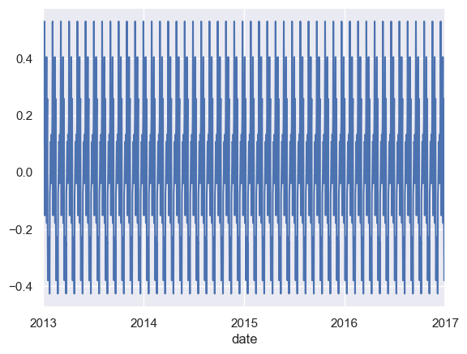

```python
decompose_data.seasonal.plot()
```

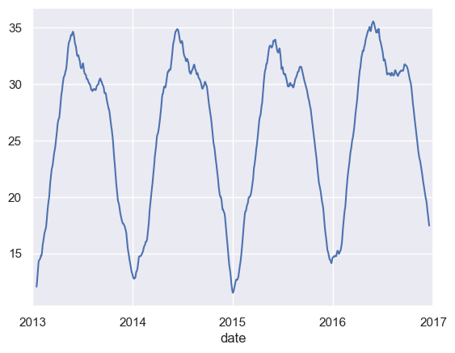

```python
decompose_data.trend.plot()
```

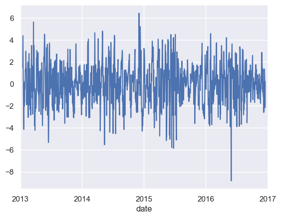

```python
decompose_data.resid.plot()
```

# Splitting data to begin building models

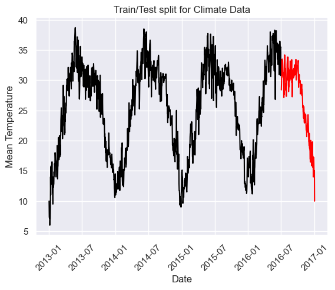

```python
train = climate[climate.index < pd.to_datetime("2016-07-01", format='%Y-%m-%d')]
test = climate[climate.index > pd.to_datetime("2016-07-01", format='%Y-%m-%d')]

#plt.plot(train, color = "black")
#plt.plot(test, color = "red")
plt.plot(train.index, train['meantemp'], color = "black")
plt.plot(test.index, test['meantemp'], color = "red")
plt.ylabel('Mean Temperature')
plt.xlabel('Date')
plt.xticks(rotation=45)
plt.title("Train/Test split for Climate Data")
plt.show()
```

##### We split the data so that anything before July 2016 is our training data and everything after July 2016 is what we will use to test the model. it is important to differentiate what the test line looks like before we apply a model to it so that we understand how accurarate our model is post test. We will compare it.

# Autocorrelation to help with our model building

```python
climate2=climate[['meantemp']]
print(climate2)
```

```
             meantemp
date
2013-01-01  10.000000
2013-01-02   7.400000
2013-01-03   7.166667
2013-01-04   8.666667
2013-01-05   6.000000
...               ...
2016-12-28  17.217391
2016-12-29  15.238095
2016-12-30  14.095238
2016-12-31  15.052632
2017-01-01  10.000000

[1462 rows x 1 columns]
```

```python
from pandas.plotting import autocorrelation_plot
from matplotlib import pyplot
```

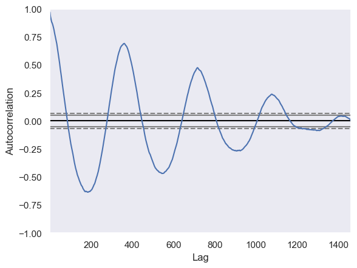

```python
autocorrelation_plot(climate2)
pyplot.show()
```

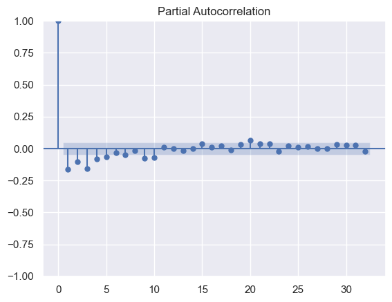

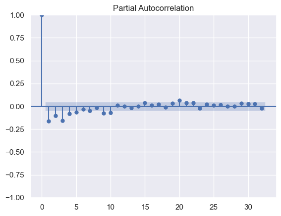

```python
from statsmodels.graphics.tsaplots import plot_pacf
plot_pacf(climate.meantemp.diff().dropna())
```

##### Here, I want to make it understood that I am using this partial autocorrelation to identify what I want to use as my P value in the Arima model. Here I see that our first lag is way out of the limit, so we will ignore it but I can see that although the second lag is out of the limit as well, it is much closer. With that being said we will test the value of either 1 or 2 for our P.

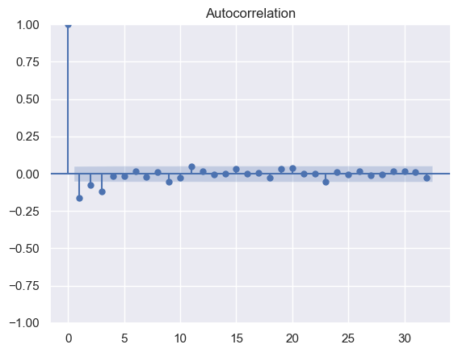

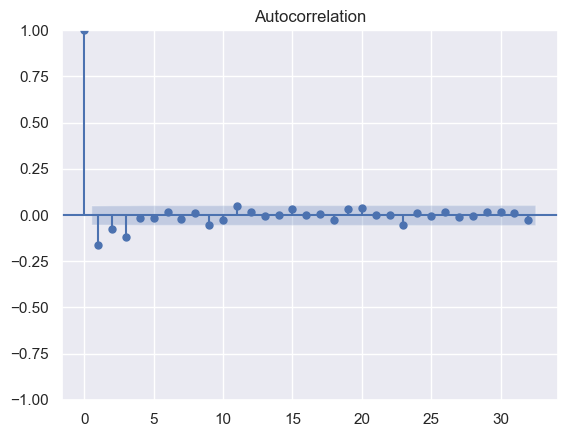

```python
from statsmodels.graphics.tsaplots import plot_acf, plot_pacf
plot_acf(climate.meantemp.diff().dropna())
```

##### Using my autocorrelation, I can only see one major instance of the lags being out of the significance limit, so here I will experiment with my q being 1. I can also try 2 or 3 and see how my results look because I do see 2 more out of the significance limit but not by much.

##### Just looking at the visualization of our data, I have come to the conclusion that not much differencing is needed with our data, So I will attempt using a value of 1 for our d in pdq.

# ARIMA Model

```python
y = train['meantemp']

ARIMAmodel = ARIMA(y, order = (1, 1, 1))
# The first parameter corresponds to the lagging (past values),
# the second corresponds to differencing (this is what makes
# non-stationary data stationary), and the last parameter corresponds
# to the white noise (for modeling shock events)
ARIMAmodel = ARIMAmodel.fit()

y_pred_2 = ARIMAmodel.get_forecast(len(test.index))
y_pred_df_2 = y_pred_2.conf_int(alpha = 0.05) #--higher alpha assigns greater weight to more recent values
y_pred_df_2["Predictions"] = ARIMAmodel.predict(start = y_pred_df_2.index[0], end = y_pred_df_2.index[-1])
y_pred_df_2.index = test.index
y_pred_out_2 = y_pred_df_2["Predictions"]
```

# SARIMA Model

```python
# Lets define our model input
y = train['meantemp']

SARIMAXmodel = SARIMAX(y, order = (1, 1, 1), seasonal_order=(1,1,1,13))
# The first 3 parameters for seasonal_order are defined the same as when treating non-seasonal
# The fourth indicates the seasonal periods to apply the parameters to
# In other words, how many observations of seasonal spikes/dips per year
SARIMAXmodel = SARIMAXmodel.fit()

y_pred_3 = SARIMAXmodel.get_forecast(len(test.index))
y_pred_df_3 = y_pred_3.conf_int(alpha = 0.05)
y_pred_df_3["Predictions"] = SARIMAXmodel.predict(start = y_pred_df_3.index[0], end = y_pred_df_3.index[-1])
y_pred_df_3.index = test.index
y_pred_out_3 = y_pred_df_3["Predictions"]
```

# Performance

```
SARIMA RMSE:  11.65329822866356
ARIMA RMSE:  9.490129237099728
```

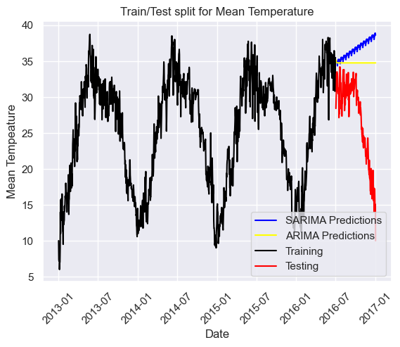

```python
plt.plot(y_pred_out_3, color='Blue', label = 'SARIMA Predictions')
plt.plot(y_pred_out_2, color='Yellow', label = 'ARIMA Predictions')
plt.plot(train.index, train['meantemp'], color = "black", label = 'Training')
plt.plot(test.index, test['meantemp'], color = "red", label = 'Testing')
plt.ylabel('Mean Tempeature')
plt.xlabel('Date')
plt.xticks(rotation=45)
plt.title("Train/Test split for Mean Temperature")
plt.legend()

sarima_rmse = np.sqrt(mean_squared_error(test["meantemp"].values, y_pred_df_3["Predictions"]))
print("SARIMA RMSE: ",sarima_rmse)

arima_rmse = np.sqrt(mean_squared_error(test["meantemp"].values, y_pred_df_2["Predictions"]))
print("ARIMA RMSE: ",arima_rmse)
```

##### I don't like my results, my RMSE (basically a measure of how far your actual values are from the models predicted values on average) is too high, for both models, I have an RMSE of 9.4 and 11.6, when some of my max values for mean temp is around 38. Also looking at the graph, my model prediction graph does not fit or comes close to fitting my original graph. I will mess around with the parameters and see if I can get better results.

# Tweaking ARIMA and SARIMA models

```python
y = train['meantemp']

ARIMAmodel = ARIMA(y, order = (5, 1, 3))

ARIMAmodel = ARIMAmodel.fit()

y_pred_2 = ARIMAmodel.get_forecast(len(test.index))
y_pred_df_2 = y_pred_2.conf_int(alpha = 0.05)
y_pred_df_2["Predictions"] = ARIMAmodel.predict(start = y_pred_df_2.index[0], end = y_pred_df_2.index[-1])
y_pred_df_2.index = test.index
y_pred_out_2 = y_pred_df_2["Predictions"]
```

```python
# Lets define our model input
y = train['meantemp']

SARIMAXmodel = SARIMAX(y, order = (5, 1, 3), seasonal_order=(5,1,3,13))

SARIMAXmodel = SARIMAXmodel.fit()

y_pred_3 = SARIMAXmodel.get_forecast(len(test.index))
y_pred_df_3 = y_pred_3.conf_int(alpha = 0.05)
y_pred_df_3["Predictions"] = SARIMAXmodel.predict(start = y_pred_df_3.index[0], end = y_pred_df_3.index[-1])
y_pred_df_3.index = test.index
y_pred_out_3 = y_pred_df_3["Predictions"]
```

```
SARIMA RMSE:  11.69474801034673
ARIMA RMSE:  9.505709508435476
```

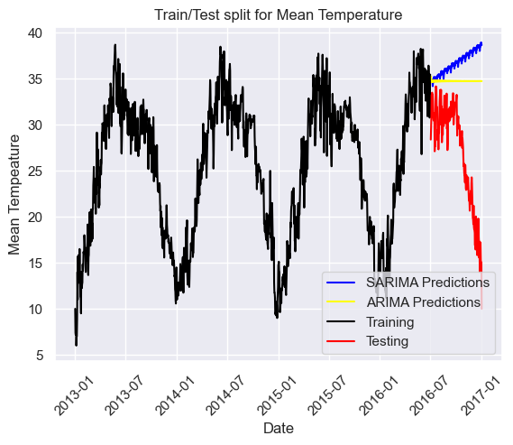

```python
plt.plot(y_pred_out_3, color='Blue', label = 'SARIMA Predictions')
plt.plot(y_pred_out_2, color='Yellow', label = 'ARIMA Predictions')
plt.plot(train.index, train['meantemp'], color = "black", label = 'Training')
plt.plot(test.index, test['meantemp'], color = "red", label = 'Testing')
plt.ylabel('Mean Tempeature')
plt.xlabel('Date')
plt.xticks(rotation=45)
plt.title("Train/Test split for Mean Temperature")
plt.legend()

sarima_rmse = np.sqrt(mean_squared_error(test["meantemp"].values, y_pred_df_3["Predictions"]))
print("SARIMA RMSE: ",sarima_rmse)

arima_rmse = np.sqrt(mean_squared_error(test["meantemp"].values, y_pred_df_2["Predictions"]))
print("ARIMA RMSE: ",arima_rmse)
```

##### I am getting similar results but it isnt caputring the data and prediciting well. I will either keep tweaking the parameters or try another model to see what works best.

### Trying different train/test split

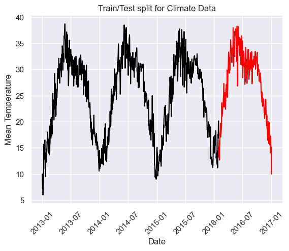

```python
train2 = climate[climate.index < pd.to_datetime("2016-02-01", format='%Y-%m-%d')]
test2 = climate[climate.index > pd.to_datetime("2016-02-01", format='%Y-%m-%d')]

#plt.plot(train, color = "black")
#plt.plot(test, color = "red")
plt.plot(train2.index, train2['meantemp'], color = "black")
plt.plot(test2.index, test2['meantemp'], color = "red")
plt.ylabel('Mean Temperature')
plt.xlabel('Date')
plt.xticks(rotation=45)
plt.title("Train/Test split for Climate Data")
plt.show()
```

### Rebuilding ARIMA and SARIMA Model With New Splits

```python
y = train2['meantemp']

ARIMAmodel = ARIMA(y, order = (5, 1, 5))

ARIMAmodel = ARIMAmodel.fit()

y_pred_2 = ARIMAmodel.get_forecast(len(test2.index))
y_pred_df_2 = y_pred_2.conf_int(alpha = 0.05)
y_pred_df_2["Predictions"] = ARIMAmodel.predict(start = y_pred_df_2.index[0], end = y_pred_df_2.index[-1])
y_pred_df_2.index = test2.index
y_pred_out_2 = y_pred_df_2["Predictions"]
```

```python
# Lets define our model input
y = train2['meantemp']

SARIMAXmodel = SARIMAX(y, order = (5, 1, 5), seasonal_order=(5,1,5,13))

SARIMAXmodel = SARIMAXmodel.fit()

y_pred_3 = SARIMAXmodel.get_forecast(len(test2.index))
y_pred_df_3 = y_pred_3.conf_int(alpha = 0.05)
y_pred_df_3["Predictions"] = SARIMAXmodel.predict(start = y_pred_df_3.index[0], end = y_pred_df_3.index[-1])
y_pred_df_3.index = test2.index
y_pred_out_3 = y_pred_df_3["Predictions"]
```

```
SARIMA RMSE:  11.588246557333134
ARIMA RMSE:  12.774350424101097
```

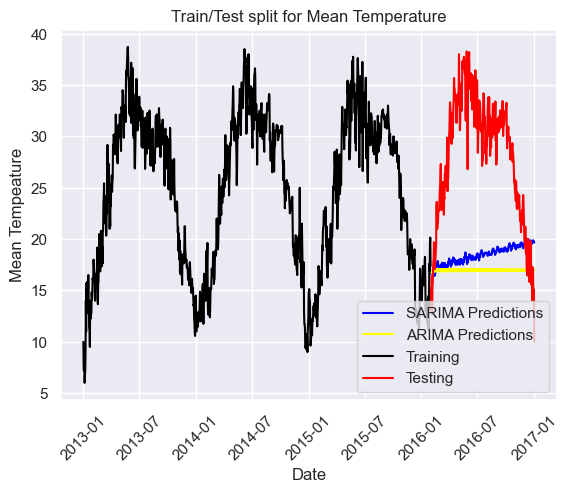

```python
plt.plot(y_pred_out_3, color='Blue', label = 'SARIMA Predictions')
plt.plot(y_pred_out_2, color='Yellow', label = 'ARIMA Predictions')
plt.plot(train2.index, train2['meantemp'], color = "black", label = 'Training')
plt.plot(test2.index, test2['meantemp'], color = "red", label = 'Testing')
plt.ylabel('Mean Tempeature')
plt.xlabel('Date')
plt.xticks(rotation=45)
plt.title("Train/Test split for Mean Temperature")
plt.legend()

sarima_rmse = np.sqrt(mean_squared_error(test2["meantemp"].values, y_pred_df_3["Predictions"]))
print("SARIMA RMSE: ",sarima_rmse)

arima_rmse = np.sqrt(mean_squared_error(test2["meantemp"].values, y_pred_df_2["Predictions"]))
print("ARIMA RMSE: ",arima_rmse)
```

##### After trying many different parameter, I am starting to realize that this ARIMA and SARIMA model is not good for seasonal time series data like the one I have here. It just does not do the job in capturing the seasonalities. I will look for better models to use and try them.

# FB Prophet Model

##### After some research, i wwas able to identify the fact that a prophet model might be best for my datat because of the amount of seasonality in this data. I will attempt to implement it here and test out my results compared to the ARIMA and SARIMA models.

```python
!pip install prophet
```

[output not shown]

```python
from prophet import Prophet
from prophet.plot import plot_plotly, plot_components_plotly
```

```python
#Pulling up my data again to be stored under a new dictionary to be easier to manipulate with FB Prophet
prophet_climate=pd.read_csv("C:\\Users\\Jordy\\Desktop\\DailyDelhiClimateTrain.csv")
prophet_climate.head()
```

|  | date | meantemp | humidity | wind_speed | meanpressure |
| --- | --- | --- | --- | --- | --- |
| 0 | 2013-01-01 | 10.000000 | 84.500000 | 0.000000 | 1015.666667 |
| 1 | 2013-01-02 | 7.400000 | 92.000000 | 2.980000 | 1017.800000 |
| 2 | 2013-01-03 | 7.166667 | 87.000000 | 4.633333 | 1018.666667 |
| 3 | 2013-01-04 | 8.666667 | 71.333333 | 1.233333 | 1017.166667 |
| 4 | 2013-01-05 | 6.000000 | 86.833333 | 3.700000 | 1016.500000 |

```python
#To create my model, I am only interested in the date and the meantemp so I am defining a new data frame from my original that only includes date and meantemp
prophet_climate2=prophet_climate[['date','meantemp']]
prophet_climate2.head()
```

|  | date | meantemp |
| --- | --- | --- |
| 0 | 2013-01-01 | 10.000000 |
| 1 | 2013-01-02 | 7.400000 |
| 2 | 2013-01-03 | 7.166667 |
| 3 | 2013-01-04 | 8.666667 |
| 4 | 2013-01-05 | 6.000000 |

```python
#Renaming date and meantemp columns because that is the labels that the prophet model has hardcoded to be able to read.
prophet_climate2.columns = ['ds','y']
```

```python
prophet_climate2.head()
```

|  | ds | y |
| --- | --- | --- |
| 0 | 2013-01-01 | 10.000000 |
| 1 | 2013-01-02 | 7.400000 |
| 2 | 2013-01-03 | 7.166667 |
| 3 | 2013-01-04 | 8.666667 |
| 4 | 2013-01-05 | 6.000000 |

```python
#Making sure that my date(ds) is converted to date time format to be able to be read by the model
prophet_climate2['ds']=pd.to_datetime(prophet_climate2['ds'])
```

```python
prophet_climate2.info()
```

```
<class 'pandas.core.frame.DataFrame'>
RangeIndex: 1462 entries, 0 to 1461
Data columns (total 2 columns):
 #   Column  Non-Null Count  Dtype
---  ------  --------------  -----
 0   ds      1462 non-null   datetime64[ns]
 1   y       1462 non-null   float64
dtypes: datetime64[ns](1), float64(1)
memory usage: 23.0 KB
```

### Train/Test Split

```python
#Setting up my training and testing splits so that my test data is for the last 365 days of my data and my training data consists of all the days before the last 365 days
trainp = prophet_climate2.iloc[:len(prophet_climate2)-365]
testp = prophet_climate2.iloc[len(prophet_climate2)-365:]
```

### Model Building

```python
#Setting up the dictionaries for my model and running the model
m=Prophet()
m.fit(trainp)
future=m.make_future_dataframe(periods=365)
forecast=m.predict(future)
```

```
03:47:28 - cmdstanpy - INFO - Chain [1] start processing
03:47:28 - cmdstanpy - INFO - Chain [1] done processing
```

```python
forecast.tail(5)
```

|  | ds | trend | yhat_lower | yhat_upper | trend_lower | trend_upper | additive_terms | additive_terms_lower | additive_terms_upper | weekly | weekly_lower | weekly_upper | yearly | yearly_lower | yearly_upper | multiplicative_terms | multiplicative_terms_lower | multiplicative_terms_upper | yhat |
| --- | --- | --- | --- | --- | --- | --- | --- | --- | --- | --- | --- | --- | --- | --- | --- | --- | --- | --- | --- |
| 1457 | 2016-12-28 | 25.502582 | 10.157044 | 15.104973 | 25.216136 | 25.795188 | -12.992934 | -12.992934 | -12.992934 | 0.189670 | 0.189670 | 0.189670 | -13.182604 | -13.182604 | -13.182604 | 0.0 | 0.0 | 0.0 | 12.509648 |
| 1458 | 2016-12-29 | 25.503282 | 9.790280 | 14.929746 | 25.215006 | 25.797102 | -13.229643 | -13.229643 | -13.229643 | 0.032101 | 0.032101 | 0.032101 | -13.261744 | -13.261744 | -13.261744 | 0.0 | 0.0 | 0.0 | 12.273639 |
| 1459 | 2016-12-30 | 25.503981 | 9.512914 | 14.426487 | 25.214009 | 25.799015 | -13.360205 | -13.360205 | -13.360205 | -0.044180 | -0.044180 | -0.044180 | -13.316025 | -13.316025 | -13.316025 | 0.0 | 0.0 | 0.0 | 12.143777 |
| 1460 | 2016-12-31 | 25.504681 | 9.583960 | 14.653934 | 25.213698 | 25.801471 | -13.452698 | -13.452698 | -13.452698 | -0.106184 | -0.106184 | -0.106184 | -13.346515 | -13.346515 | -13.346515 | 0.0 | 0.0 | 0.0 | 12.051983 |
| 1461 | 2017-01-01 | 25.505381 | 9.346984 | 14.237332 | 25.213387 | 25.804093 | -13.579498 | -13.579498 | -13.579498 | -0.224934 | -0.224934 | -0.224934 | -13.354563 | -13.354563 | -13.354563 | 0.0 | 0.0 | 0.0 | 11.925883 |

```python
forecast[['ds','yhat']].tail()
```

|  | ds | yhat |
| --- | --- | --- |
| 1457 | 2016-12-28 | 12.509648 |
| 1458 | 2016-12-29 | 12.273639 |
| 1459 | 2016-12-30 | 12.143777 |
| 1460 | 2016-12-31 | 12.051983 |
| 1461 | 2017-01-01 | 11.925883 |

##### As you can see here, all that we are really worried about is the yhat value and the date. The yhat value tells us essentially what the models predictions are for the given date.

```python
prophet_climate2.tail()
```

|  | ds | y |
| --- | --- | --- |
| 1457 | 2016-12-28 | 17.217391 |
| 1458 | 2016-12-29 | 15.238095 |
| 1459 | 2016-12-30 | 14.095238 |
| 1460 | 2016-12-31 | 15.052632 |
| 1461 | 2017-01-01 | 10.000000 |

# Visualizing Results From Prophet Model

```python
plot_plotly(m, forecast)
```

[interactive chart not shown]

##### Here we see that the solid blue line is the predictions of my model and the black dots are my actual values. As you can see, the model did pretty well in predicting the values. It did much better than using ARIMA and SARIMA.

```python
from statsmodels.tools.eval_measures import rmse
```

```python
predictions= forecast.iloc[-365:]['yhat']
```

```python
print('Root Mean Squared Error Is: ',rmse(predictions,testp['y']))
```

```
Root Mean Squared Error Is:  2.8156775368652815
```

##### Hear we have calculated our RMSE for the prophet model which is SIGNIFICANTLY lower than what we were getting for the ARIMA and SARIMA models, so we can easily say that this model is probably best for forecasting our data.